# Adaptive PDAC

# The simpson index

The index ranges between 0-1, where 1 = high diversity and 0 = no diversity

Matrix with the distribution scores: Distribution levels; below called “Intensity scores. This category represents the fraction of positive cells in each ROI:

- 0-5% 0
- 5-20 % 1
- 20-40% 2
- 40-60% 3
- 60-80% 4
- 80-95% 5
- 95-100% 6

```r
sim_all_c6$`2` #Example of how the data matrix looks like, for just one case, PKR-2
```

```
##     CA125      CDX2      CK17       CK5     HMGA2      Muc5
## 0.8104575 0.5032680 0.8104575 0.6601307 0.7124183 0.8366013
```

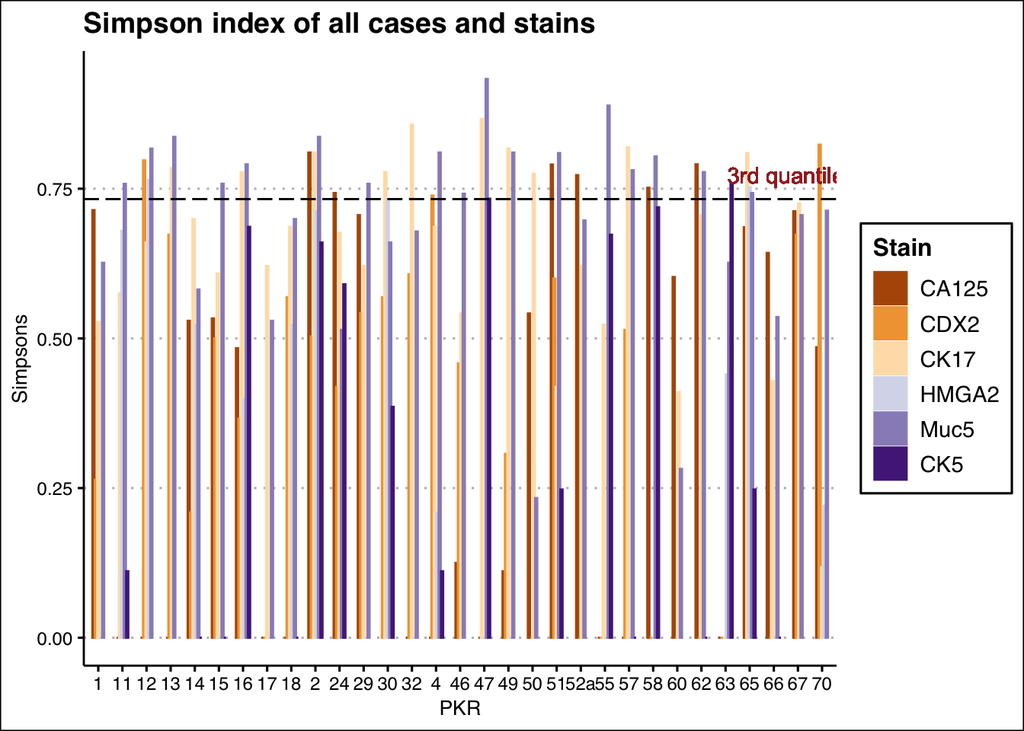

```r
ggplot(simpsons_2, aes(x=PKR, y=Simpsons,
                     color = Stain, fill = Stain,
                     position = "dodge")) +
  geom_bar(stat = "identity", width=0.6, position = position_dodge2(width = 0.5, preserve = "single")) +
  scale_fill_brewer(palette = "PuOr") +
  scale_color_brewer(palette = "PuOr") +
  geom_hline(yintercept = simpline,linetype = "longdash") +
  geom_text(aes(29.5, simpline, label = "3rd quantile", vjust = -1), col = "brown") +
  labs(title = "Simpson index of all cases and stains") +
  theme_clean()
```

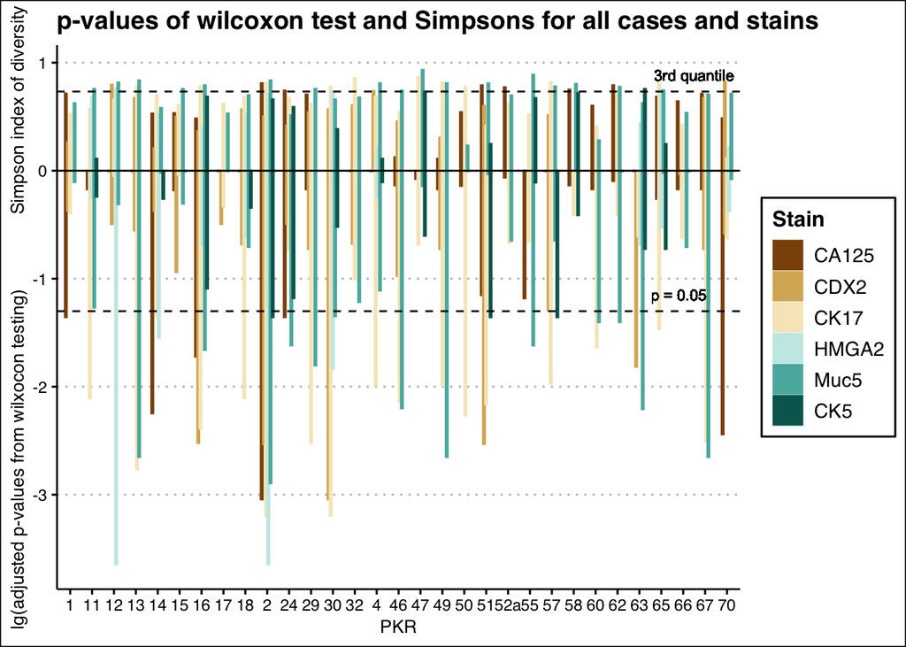

```r
ggplot(simpsons_lgpval_2, aes(x=PKR,
                            color = Stain, fill = Stain,
                            position = "dodge")) +
  geom_bar(aes(y = p_val), stat = "identity", width=0.6, position = position_dodge2(width = 0.5, preserve = "single")) +
  geom_bar(aes(y = Simpsons), stat = "identity", width=0.6, position = position_dodge2(width = 0.5, preserve = "single")) +
  scale_fill_brewer(palette= "BrBG", type = "div") +
  scale_color_brewer(palette= "BrBG", type = "div") +
  geom_hline(yintercept = log10(pline), linetype = "dashed", color = "black") +
  geom_text(aes(29.5, simpline, label = "3rd quantile", vjust = -1), size = 3, col = "black") +
  geom_text(aes(28.8, log10(pline), label = "p = 0.05", vjust = -1), size = 3, col = "black") +
  geom_hline(yintercept = simpline,linetype = "dashed", col = "black") +
  geom_hline(yintercept = 0,linetype = "solid", color = "black")+
  labs(title = "p-values of wilcoxon test and Simpsons for all cases and stains") +
  ylab(c("lg(adjusted p-values from wilxocon testing)               Simpson index of diversity")) +
  theme_clean()
```

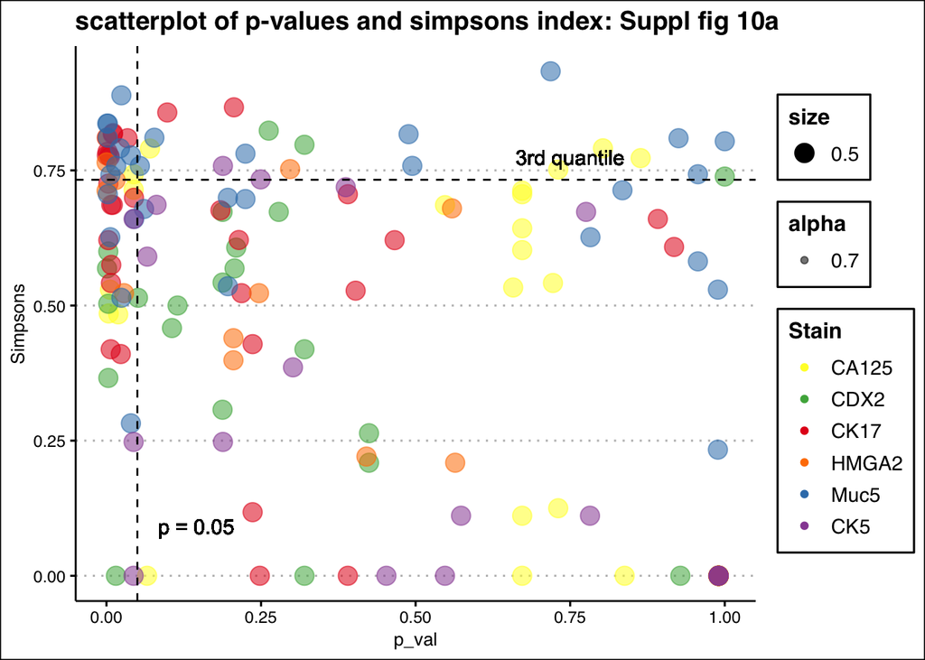

```r
# Scatterplot

x_line <- simpsons_pval_2$p_val
y_line <- simpsons_pval_2$Simpsons

scatter_simppval <- ggplot(simpsons_pval_2, aes(p_val, Simpsons, color = Stain), size = 4, alpha = 0.8)


Suppl_Fig_10a <- scatter_simppval + geom_point(aes(alpha = 0.7, size = 0.5)) +
  ggtitle("scatterplot of p-values and simpsons index: Suppl fig 10a") +
  geom_hline(yintercept = simpline,linetype = "dashed", col = "black") +
  geom_text(aes(0.75, simpline, label = "3rd quantile", vjust = -1), size = 4, col = "black") +
  geom_vline(xintercept = pline, linetype = "dashed", color = "black") +
  geom_text(aes(0.15, pline, label = "p = 0.05 ", vjust = -1), size = 4, col = "black") +
  scale_color_manual(values =
                       c("CK17"="#e41a1c", "CK5"="#984ea3", "HMGA2" = "#ff7f00", "CA125" = "#ffff33", "CDX2" = "#4daf4a", "Muc5" = "#377eb8"))+
  theme_clean()

Suppl_Fig_10a
```

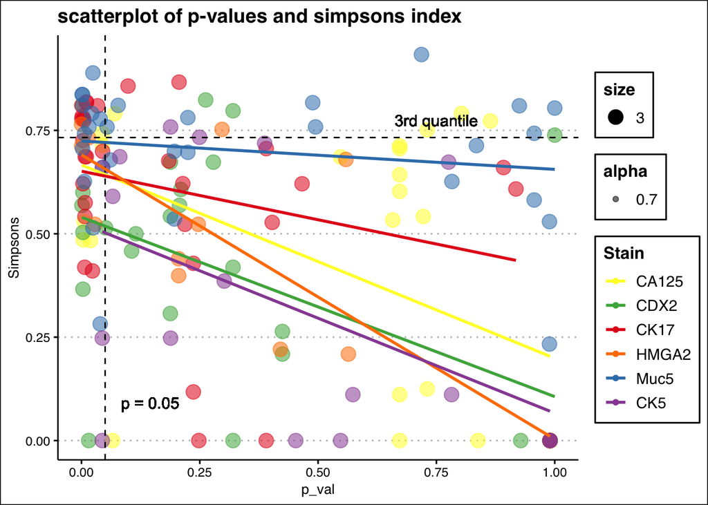

```r
scatter_simppval + geom_point(aes(alpha = 0.7, size = 3)) +
  ggtitle("scatterplot of p-values and simpsons index") +
  geom_hline(yintercept = simpline,linetype = "dashed", col = "black") +
  geom_text(aes(0.75, simpline, label = "3rd quantile", vjust = -1), size = 4, col = "black") +
  geom_vline(xintercept = pline, linetype = "dashed", color = "black") +
  geom_text(aes(0.15, pline, label = "p = 0.05 ", vjust = -1), size = 4, col = "black") +
  scale_color_manual(values =
                       c("CK17"="#e41a1c", "CK5"="#984ea3", "HMGA2" = "#ff7f00", "CA125" = "#ffff33", "CDX2" = "#4daf4a", "Muc5" = "#377eb8"))+
  geom_smooth(method = "lm", se = FALSE) +
  theme_clean()
```

```r
simpsons_pval_3 <- simpsons_pval_2
simpsons_pval_3$Event_simp_above <- factor(186)
simpsons_pval_3$Event_pval_below <- factor(186)

simpsons_pval_3 <- simpsons_pval_3 %>% mutate(Event_simp_above = ifelse(Simpsons >= simpline,
                                                                  'true', .$Event_simp_above))
simpsons_pval_3 <- simpsons_pval_3 %>% mutate(Event_pval_below = ifelse(p_val <= pline,
                                                                  'true', .$Event_pval_below))

simpsons_pval_3 <- simpsons_pval_3 %>% mutate(Event_simp_above = ifelse(Event_simp_above != "true",
                                                                  'false', .$Event_simp_above))
simpsons_pval_3 <- simpsons_pval_3 %>% mutate(Event_pval_below = ifelse(Event_pval_below != "true",
                                                                  'false', .$Event_pval_below))
simpsons_pval_4 <- simpsons_pval_3[, c(1, 3, 5:7)]
simpsons_pval_4[is.na(simpsons_pval_4)] <- 'false'
simpsons_venn <- simpsons_pval_4[, c(3, 4, 5)]
simpsons_venn <- simpsons_venn  %>% mutate(across(starts_with("Event"), as.logical))

Vennfunc <- lapply(simpsons_venn[, c(2, 3)], function (x)
  which(x == 1))

Venn_simp_pval <- ggVennDiagram(Vennfunc)

Suppl_Fig_10b_old <- Venn_simp_pval +
  scale_fill_gradient(low = "#0072B2", high = "#CC79A7")
  scale_colour_gradient(low = "#0072B2", high = "#CC79A7")
```

```
## <ScaleContinuous>
##  Range:
##  Limits:    0 --    1
```

```r
  theme_cleantable()
```

[output not shown]

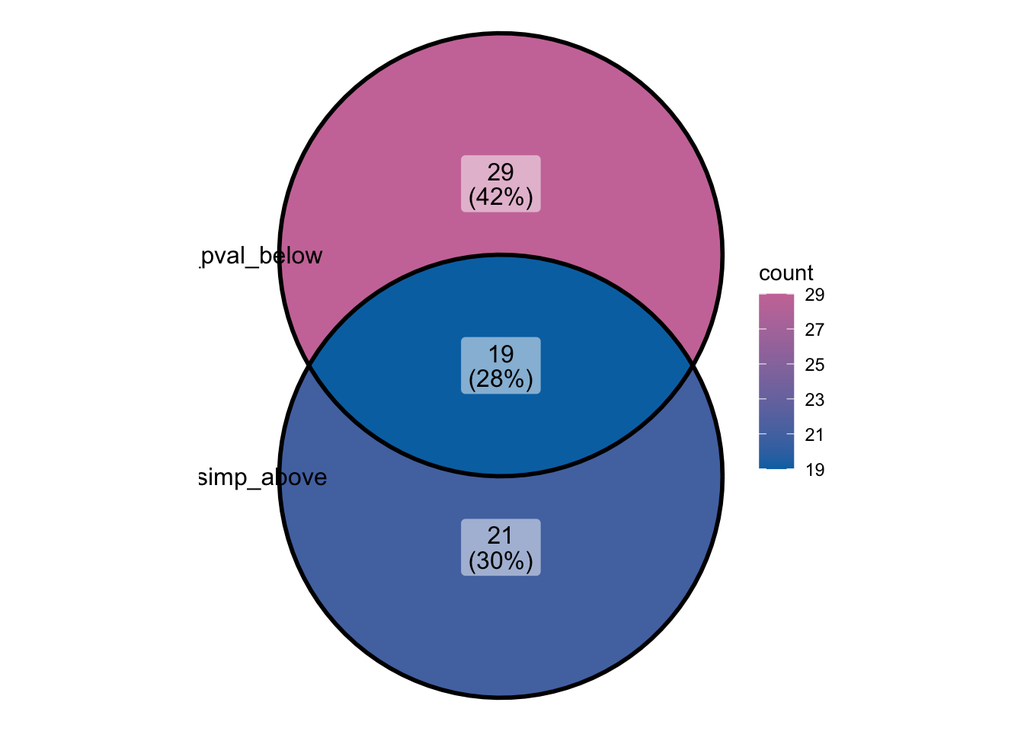

```r
Suppl_Fig_10b_old #color changed
```

```
## [1] "x total: 40"
## [1] "y total: 48"
## [1] "z total: 0"
## [1] "x only: 21"
## [1] "y only: 29"
## [1] "z only: 0"
## [1] "x-y total overlap: 19"
## [1] "x-z total overlap: 0"
## [1] "y-z total overlap: 0"
## [1] "x-y only overlap: 19"
## [1] "x-z only overlap: 0"
## [1] "y-z only overlap: 0"
## [1] "x-y-z overlap: 0"
```

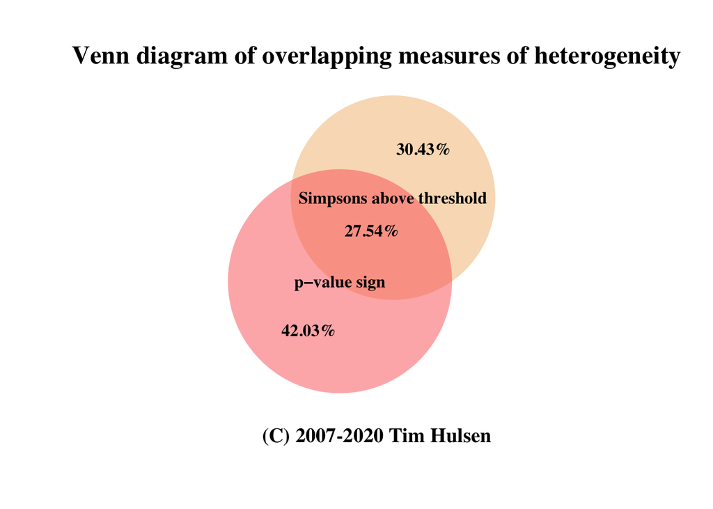

```r
# Venn, version where the size of Venn circles correspond to the numbers of cells in the respective group
# colors now correspond to the group identity instead of nr of ROIs in each group.
listed_z <- NULL

propVenn <- draw.venn(list_x = Vennfunc$Event_simp_above, list_y = Vennfunc$Event_pval_below, list_z = listed_z, title = "Venn diagram of overlapping measures of heterogeneity", xtitle = "Simpsons above threshold", ytitle = "p−value sign", x_c = "#F1BB7B", y_c = "#FD6467",  nrtype = "pct")
```

```r
Suppl_Fig_10b_new <- propVenn
Suppl_Fig_10b_new
```

```
## $x
##  [1]  10  11  19  20  23  25  32  44  58  62  65  68  71  72  75  76  77  81  86
## [20]  92 108 112 113 114 116 117 120 122 125 126 127 128 130 132 133 134 136 138
## [39] 151 157
##
## $y
##  [1]   1   5   7  10  11  30  36  39  42  48  55  60  62  63  65  67  68  70  71
## [20]  73  74  76  77  78  81  83  86  88  92  93  98 100 114 117 120 121 122 123
## [39] 126 128 132 135 136 137 140 147 152 154
##
## $z
## NULL
##
## $x_only
##  [1]  19  20  23  25  32  44  58  72  75 108 112 113 116 125 127 130 133 134 138
## [20] 151 157
##
## $y_only
##  [1]   1   5   7  30  36  39  42  48  55  60  63  67  70  73  74  78  83  88  93
## [20]  98 100 121 123 135 137 140 147 152 154
##
## $z_only
## NULL
##
## $xy
##  [1]  10  11  62  65  68  71  76  77  81  86  92 114 117 120 122 126 128 132 136
##
## $xz
## NULL
##
## $yz
## NULL
##
## $xy_only
##  [1]  10  11  62  65  68  71  76  77  81  86  92 114 117 120 122 126 128 132 136
##
## $xz_only
## NULL
##
## $yz_only
## NULL
##
## $xyz
## NULL
```

```r
simppval_return <- simpsons_venn %>%
  group_by(Event_pval_below, Event_simp_above) %>%
  summarise(N.events = n())
simppval_return
```

```
## # A tibble: 4 × 3
## # Groups:   Event_pval_below [2]
##   Event_pval_below Event_simp_above N.events
##   <lgl>            <lgl>               <int>
## 1 FALSE            FALSE                  90
## 2 FALSE            TRUE                   21
## 3 TRUE             FALSE                  29
## 4 TRUE             TRUE                   19
```

```r
simpson_return_perstain <- simpsons_pval_2 %>%
  group_by(Stain) %>%
  summarise(N.instances = n())

simpson_return_perstain
```

```
## # A tibble: 6 × 2
##   Stain N.instances
##   <fct>       <int>
## 1 CA125          30
## 2 CDX2           28
## 3 CK17           31
## 4 HMGA2          21
## 5 Muc5           31
## 6 CK5            18
```

```r
sum(simpson_return_perstain$N.instances)
```

```
## [1] 159
```

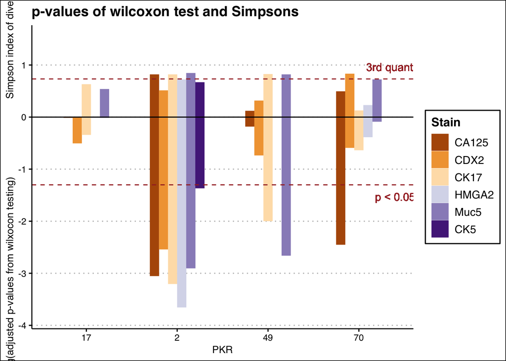

```r
ggplot(exlg_simpson_pval_2, aes(x=PKR,
                              color = Stain, fill = Stain,
                              position = "dodge")) +
  geom_bar(aes(y = p_val), stat = "identity", width=0.6, position = position_dodge2(width = 0.5, preserve = "single")) +
  geom_bar(aes(y = Simpsons), stat = "identity", width=0.6, position = position_dodge2(width = 0.5, preserve = "single")) +
  scale_fill_brewer(palette = "PuOr") +
  scale_color_brewer(palette = "PuOr") +
  geom_hline(yintercept = log10(pline), linetype = "dashed", color = "brown") +
  geom_hline(yintercept = simpline,linetype = "dashed", color = "brown") +
  geom_hline(yintercept = 0,linetype = "solid", color = "black")+
  geom_text(aes(4.4, log10(pline), label = "p < 0.05", vjust = 2), col = "brown") +
  geom_text(aes(4.4, simpline, label = "3rd quantile", vjust = -1), col = "brown") +
  labs(title = "p-values of wilcoxon test and Simpsons") +
  ylab(c("log(adjusted p-values from wilxocon testing)                            Simpson index of diversity")) +
  ylim(-3.8, 1.5) +
  theme_clean()
```

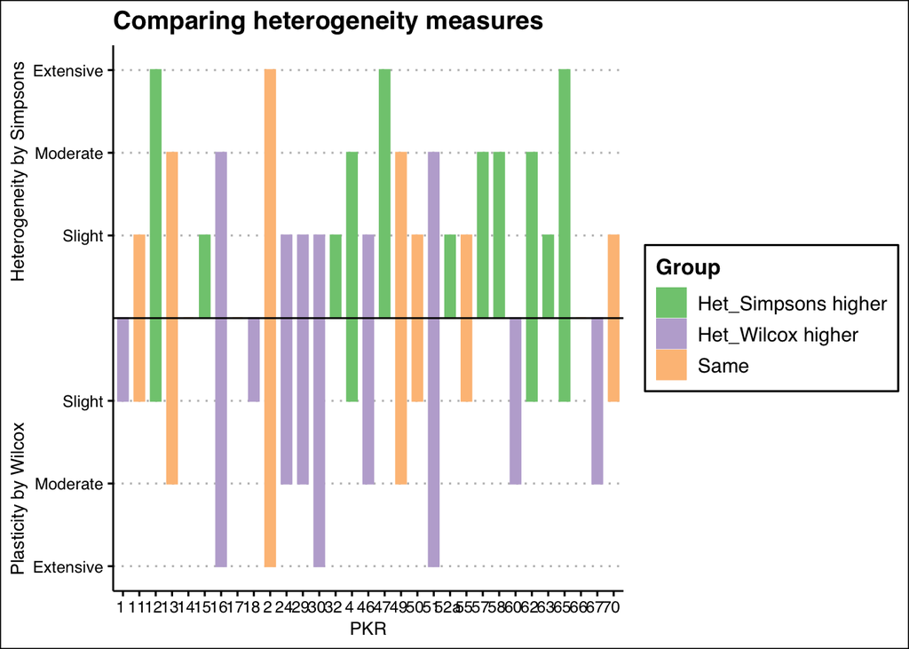

[figure not shown]

[figure not shown]

```r
ggplot(het, aes(x=PKR, position = "dodge", color = Group, fill = Group)) +
  geom_bar(aes(y = Heterogeneity_Cat), stat = "identity", width=0.6, position = position_dodge2(width = 0.5, preserve = "single")) +
  geom_bar(aes(y = -Plasticity_Cat), stat = "identity", width = 0.6, position = position_dodge2(width = 0.5, preserve = "single")) +
  scale_fill_brewer(palette = "Accent") +
  scale_color_brewer(palette = "Accent") +
  geom_hline(yintercept = 0,linetype = "solid", color = "black")+
  labs(title = "Comparing heterogeneity measures") +
  ylab(c("Plasticity by Wilcox                            Heterogeneity by Simpsons")) +
  scale_y_continuous(breaks=c(-3, -2, -1, 1, 2, 3), label= c("Extensive", "Moderate", "Slight", "Slight", "Moderate", "Extensive")) +
  theme_clean()
```

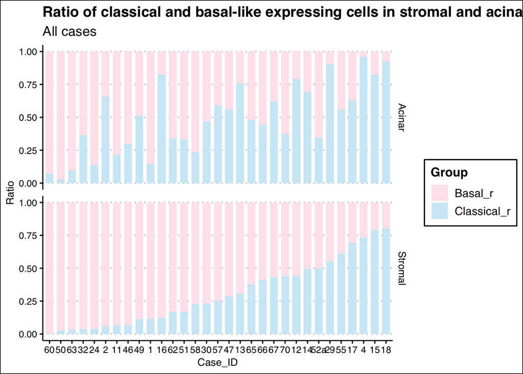

```r
sp +
  facet_grid(ROI ~ .)+ #sort on (basal like) expression in stroma.
  labs(title = "Ratio of classical and basal-like expressing cells in stromal and acinar ROIs", subtitle = "All cases")
```

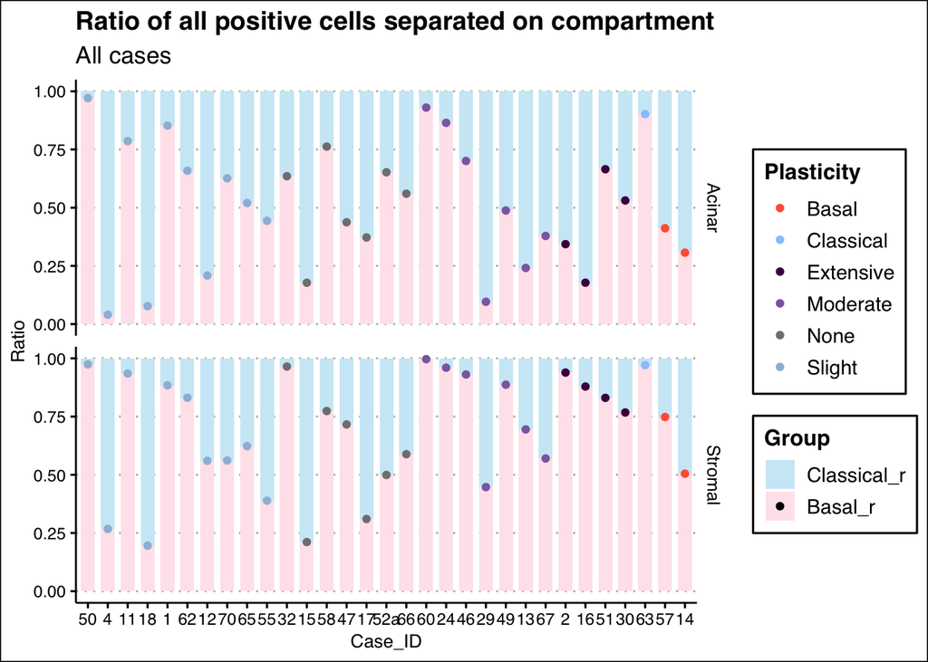

```r
Ratio_joined +
  facet_grid(ROI ~ .) +
  geom_point(aes(color=Plasticity, alpha = Group)) +
  scale_colour_manual(values = c(Extensive = "#4D004B", Moderate = "#8C6BB1", Slight = "#9EBCDA", None = "#808080", Classical = "#97C8FF", Basal = "#FF6242")) +
  scale_alpha_discrete(range=c(0, 1))+
  labs(title = "Ratio of all positive cells separated on compartment", subtitle = "All cases")
```

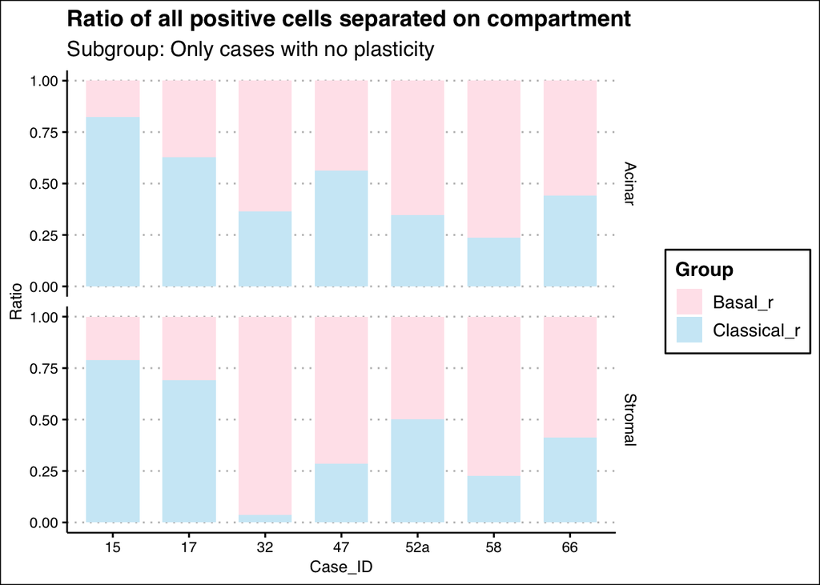

```r
sp_noplast +
  facet_grid(ROI ~ .) #sort on (basal like) expression in stroma.
```

# Distribution of % positive cells for all cases

# Basal stains in stroma. First, all pooled, followed by the individual stains.

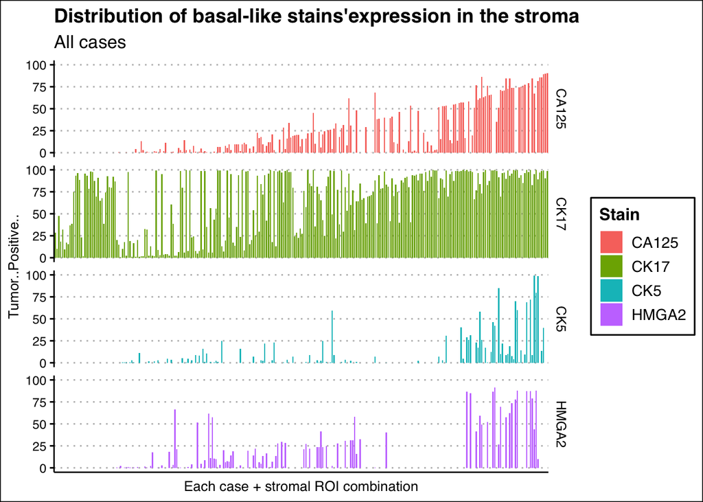

```r
distrib_stroma_basal
```

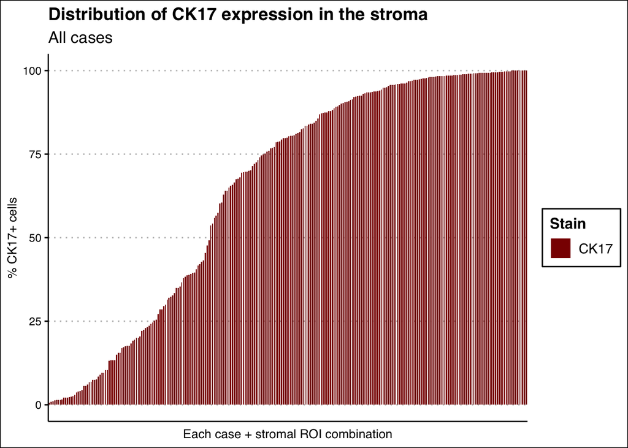

```r
distrib_stroma_CK17
```

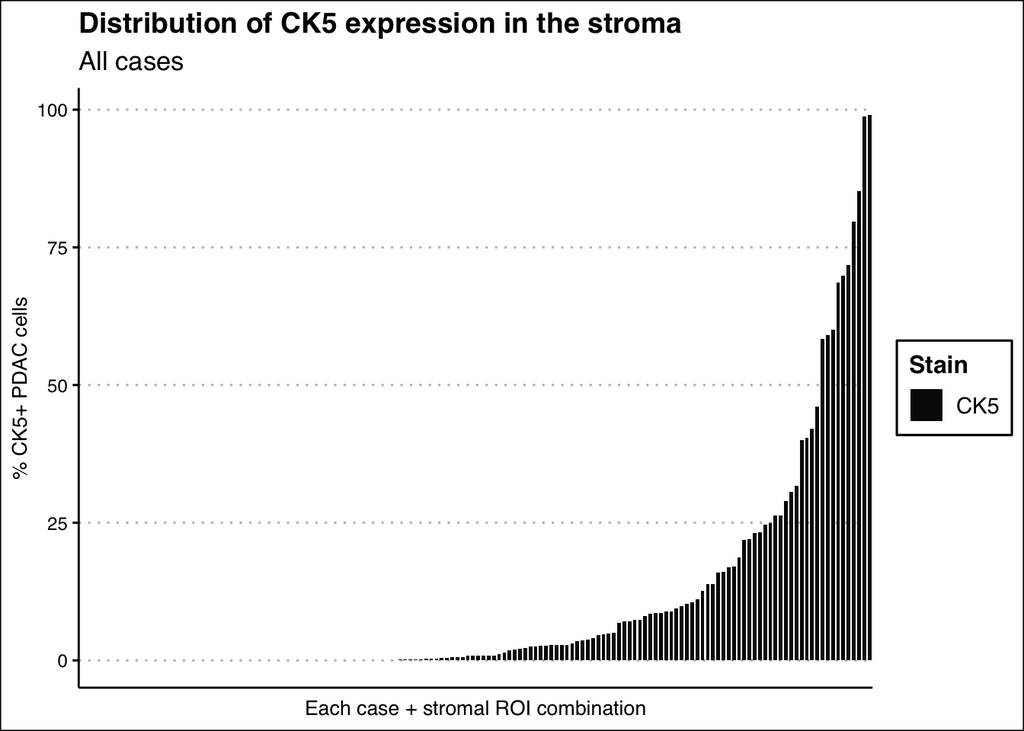

```r
distrib_stroma_CK5
```

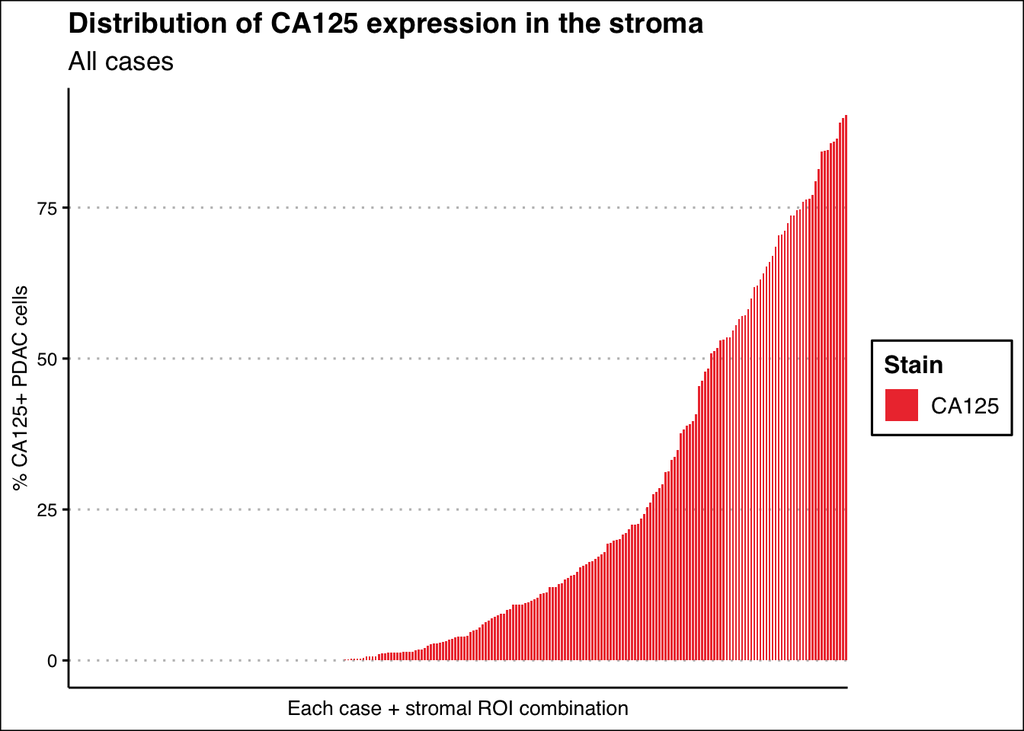

```r
distrib_stroma_CA125
```

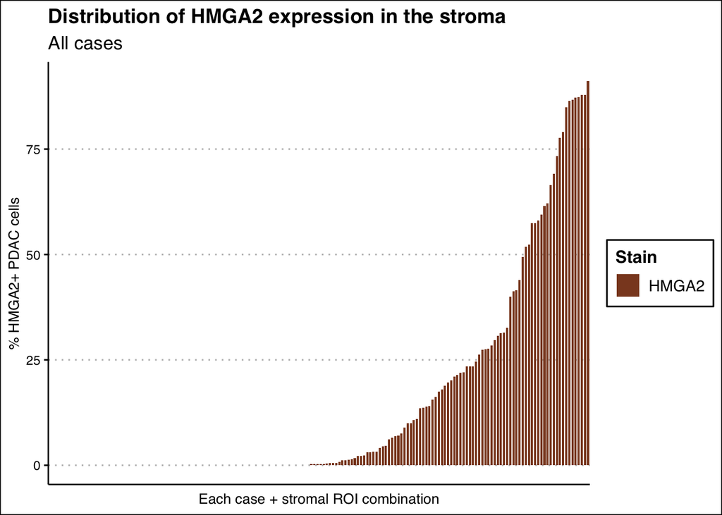

```r
distrib_stroma_HMGA2
```

# Classical stains in stroma. First, all pooled, followed by the individual stains.

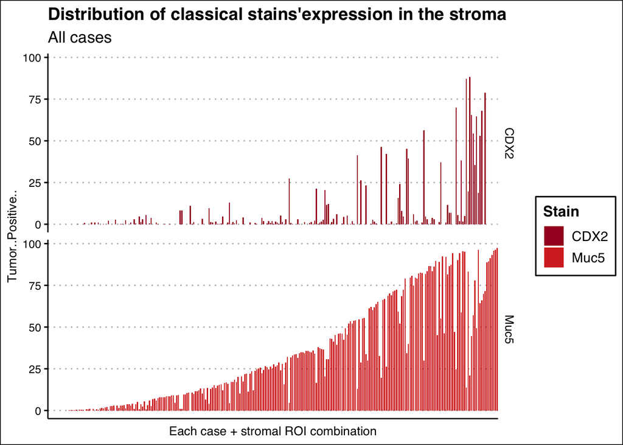

```r
distrib_stroma_classical
```

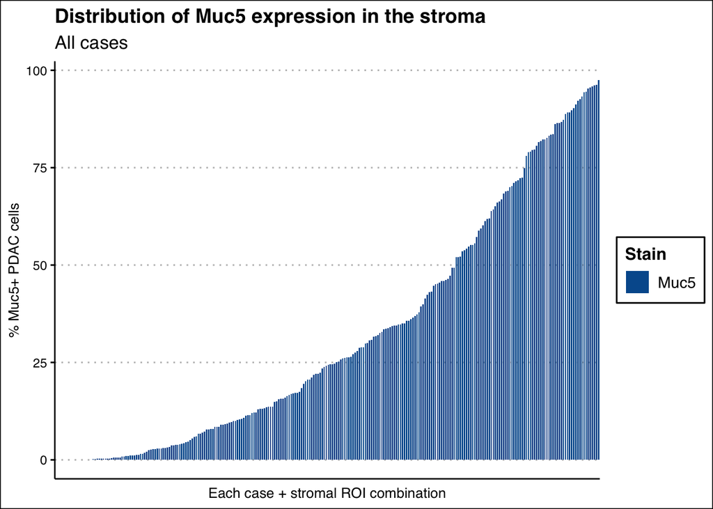

```r
distrib_stroma_Muc5
```

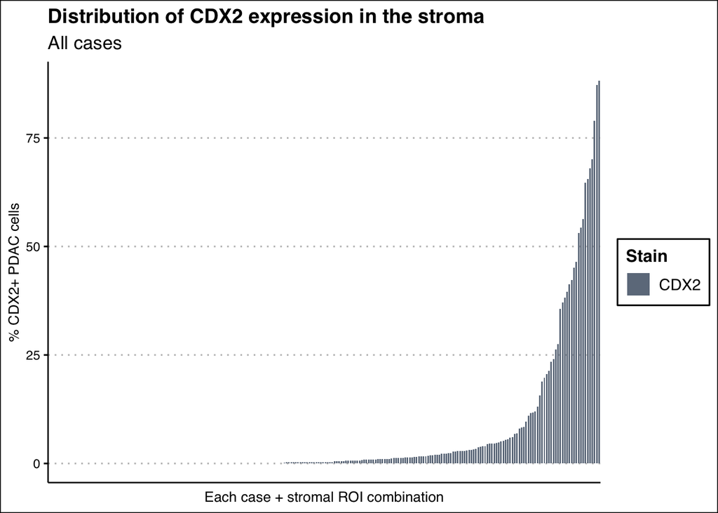

```r
distrib_stroma_CDX2
```

# Basal stains in lobular regions. First, all pooled, followed by the individual stains.

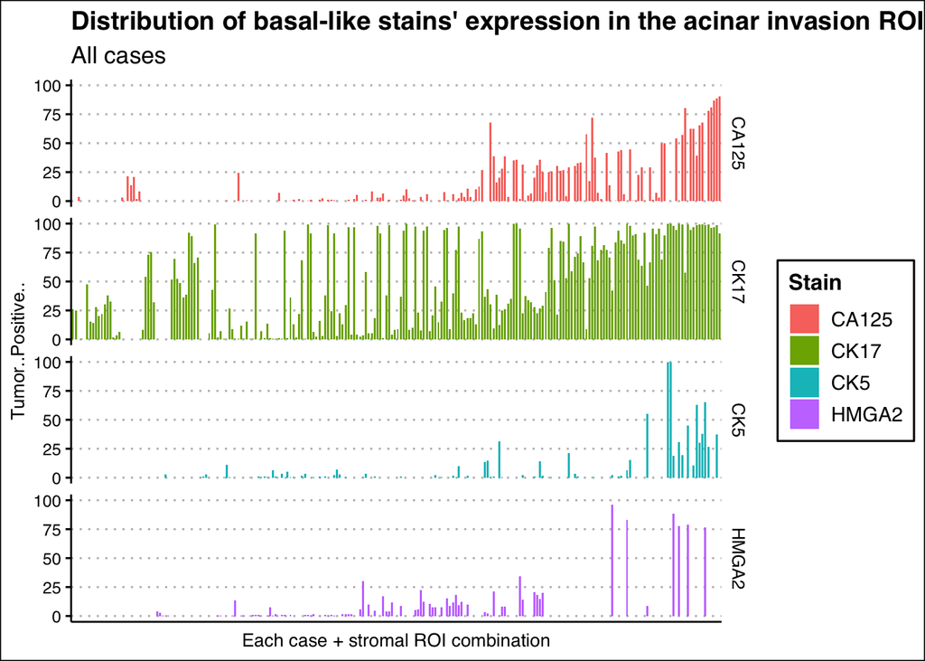

```r
distrib_lobule_basal
```

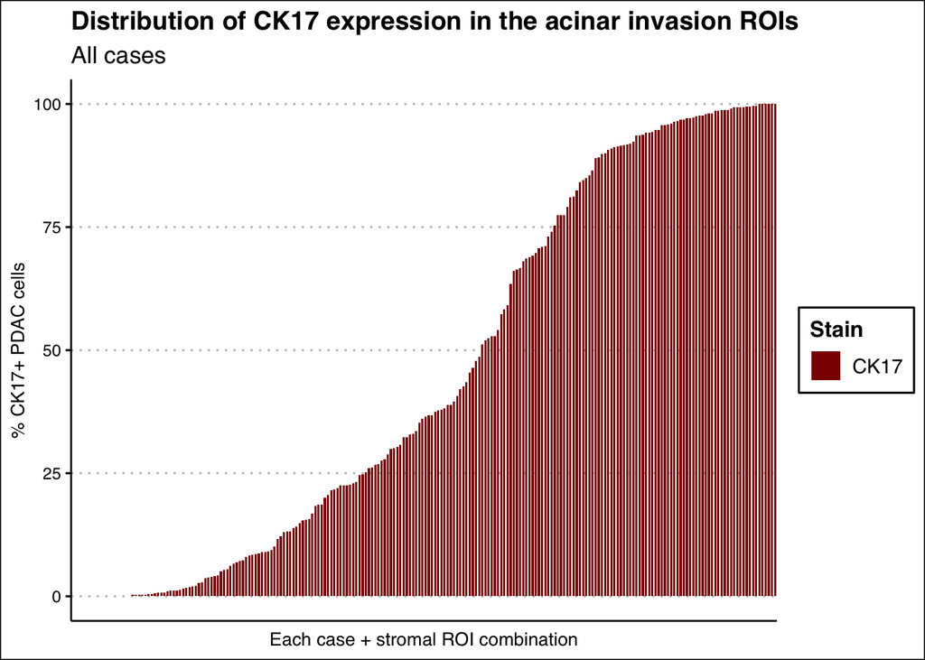

```r
distrib_lobule_CK17
```

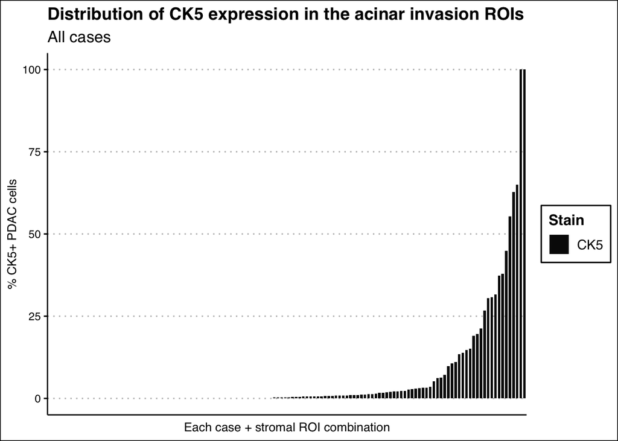

```r
distrib_lobule_CK5
```

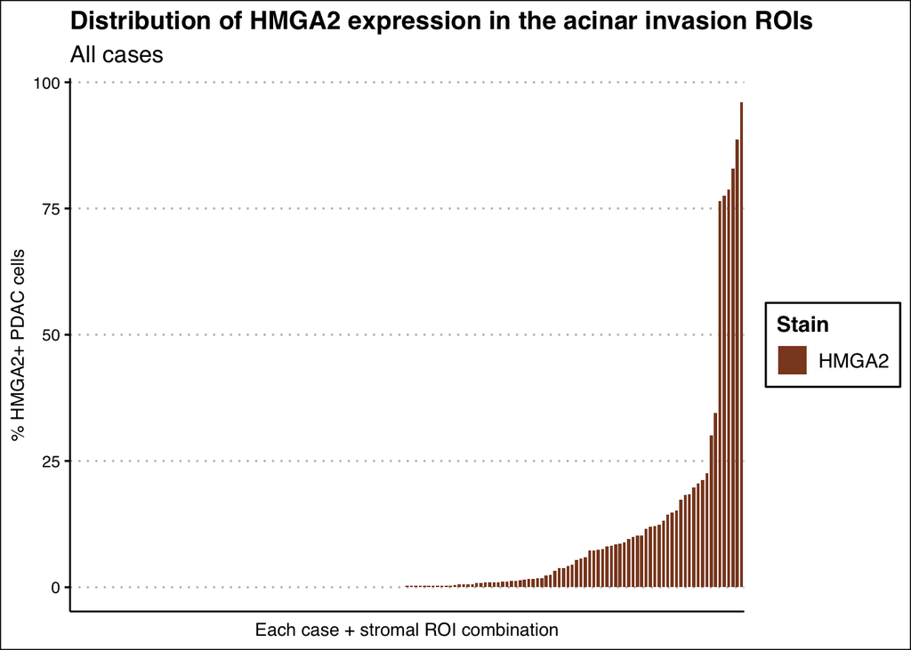

```r
distrib_lobule_HMGA2
```

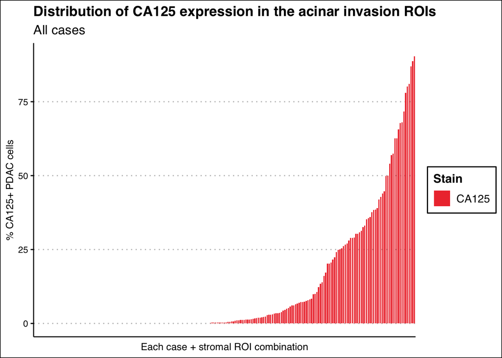

```r
distrib_lobule_CA125
```

# Classical stains in acinar. First, all pooled, followed by the individual stains.

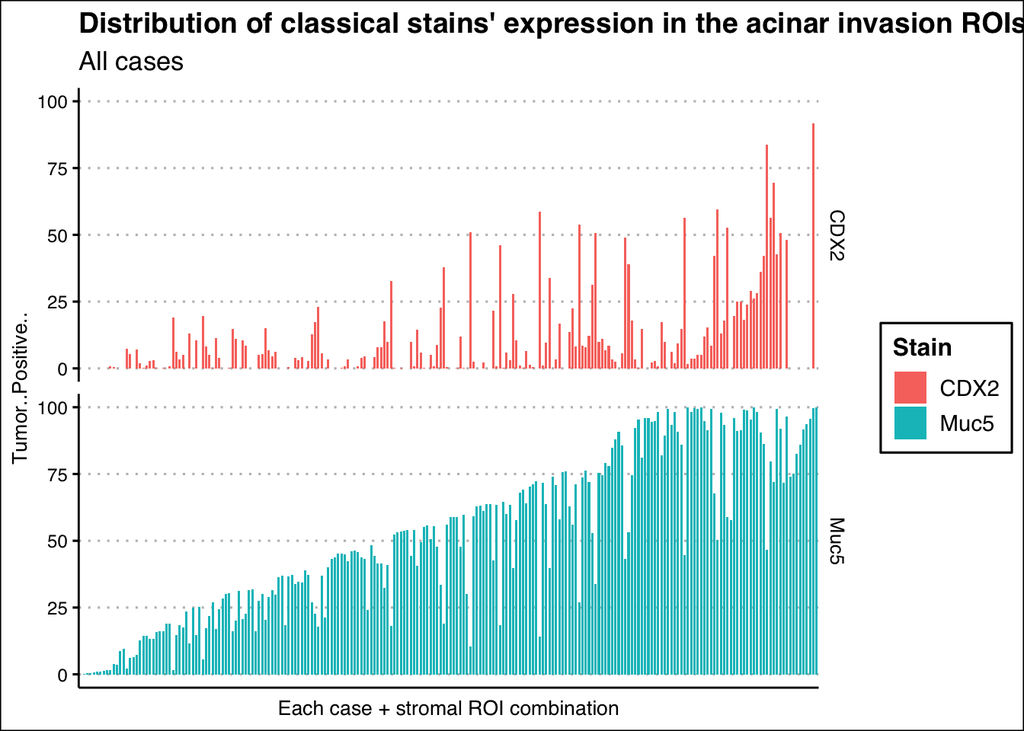

```r
distrib_lobule_classical
```

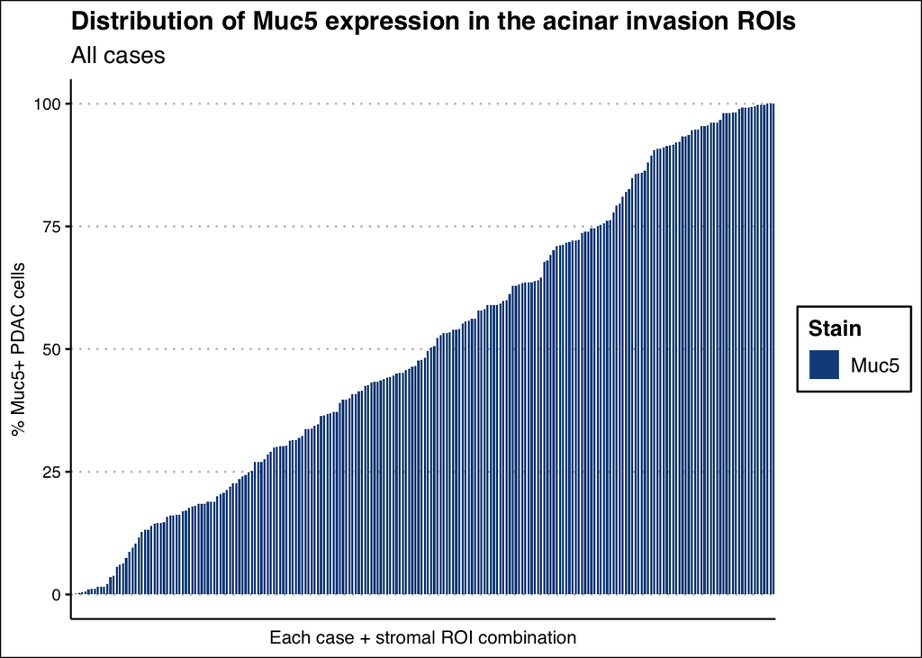

```r
distrib_lobule_Muc5
```

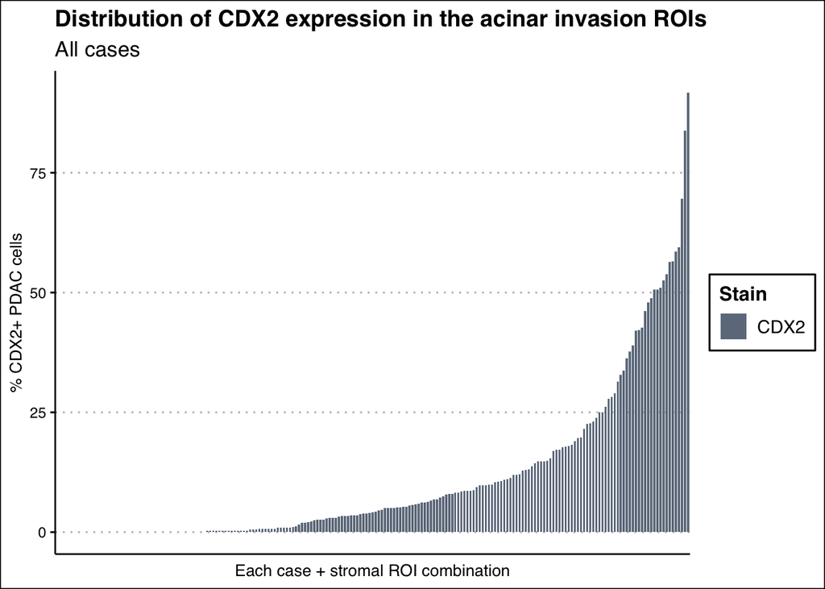

```r
distrib_lobule_CDX2
```

Density plots, separated on compartment using the datasets distrib_s and distrib_a

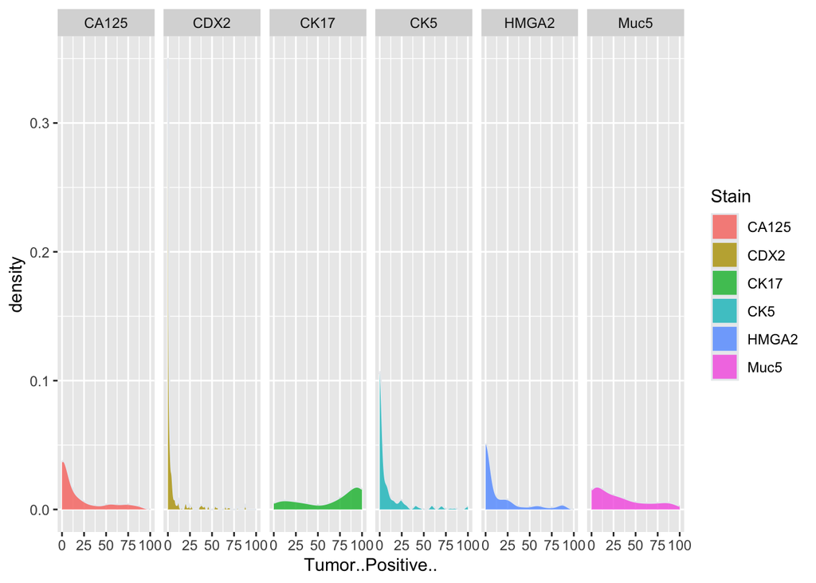

```r
density_stroma <- distrib_s %>%
  ggplot(aes(x = Tumor..Positive.., fill = Stain)) +
  geom_density(color="#e9ecef", alpha=0.8) +
  facet_grid(~Stain)

density_stroma
```

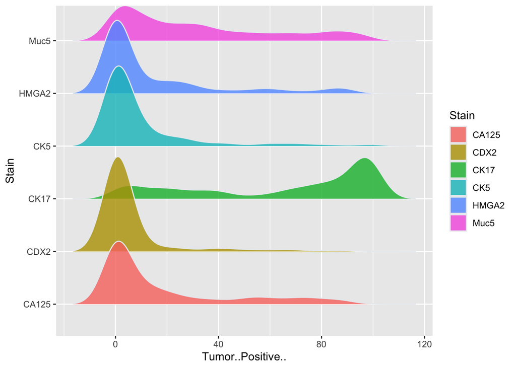

```r
#As ridgeline
ridges_stroma <- distrib_s %>%
  ggplot(aes(x = Tumor..Positive.., y = Stain, fill = Stain)) +
  geom_density_ridges(color="#e9ecef", alpha=0.8)

ridges_stroma
```

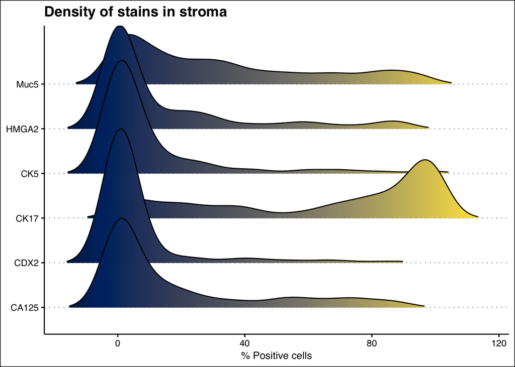

```r
#As ridgeline with color gradient
ridges_gradient_stroma <- ggplot(distrib_s, aes(x = `Tumor..Positive..`, y = `Stain`, fill = ..x..)) +
  geom_density_ridges_gradient(scale = 3, rel_min_height = 0.01) +
  scale_fill_viridis(name = "Temp. [F]", option = "E") +
  labs(title = 'Density of stains in stroma') +
  theme_clean() +
    theme(
      legend.position="none",
      panel.spacing = unit(0.1, "lines"),
      strip.text.x = element_text(size = 8)
    )+
  xlab("% Positive cells") + ylab(NULL)
ridges_gradient_stroma
```

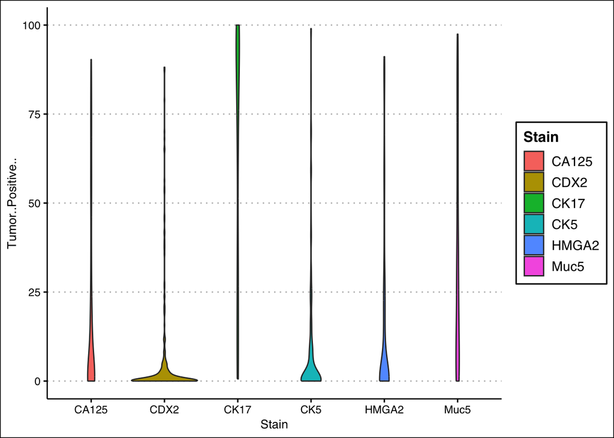

```r
# Violin plots
violin_stroma_trimmed <- distrib_s %>%
  ggplot(aes(x = Stain, y = Tumor..Positive.., fill = Stain)) +
  geom_violin(trim = TRUE) +
  theme_clean()

violin_stroma_trimmed
```

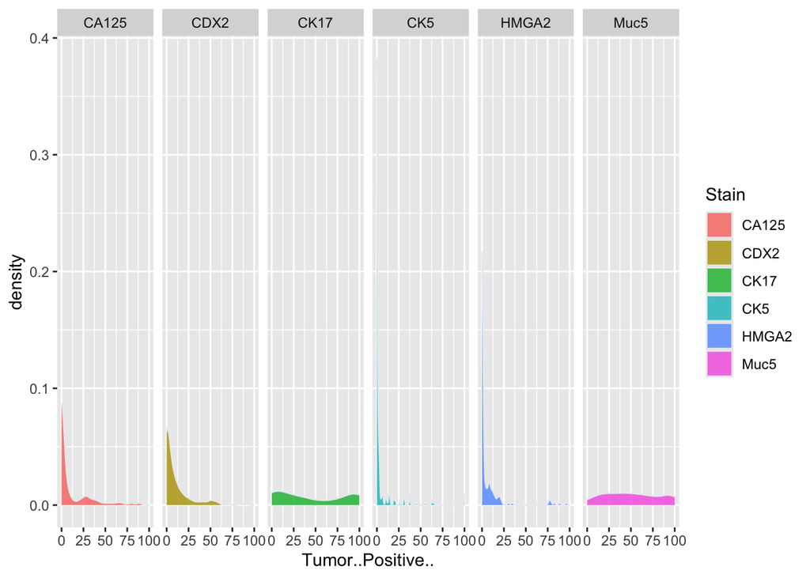

```r
density_lobule <- distrib_a %>%
  ggplot(aes(x = Tumor..Positive.., fill = Stain)) +
  geom_density(color="#e9ecef", alpha=0.8) +
  facet_grid(~Stain)

density_lobule
```

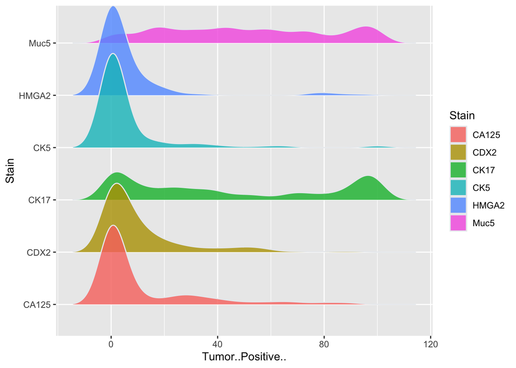

```r
#As ridgeline
ridges_lobule <- distrib_a %>%
  ggplot(aes(x = Tumor..Positive.., y = Stain, fill = Stain)) +
  geom_density_ridges(color="#e9ecef", alpha=0.8)

ridges_lobule
```

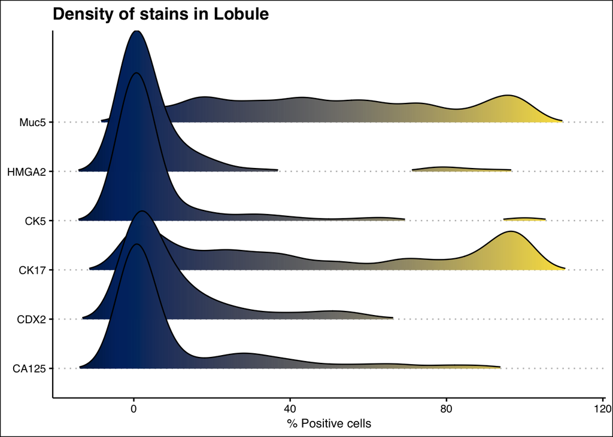

```r
#As ridgeline with color gradient
ridges_gradient_lobule <- ggplot(distrib_a, aes(x = `Tumor..Positive..`, y = `Stain`, fill = ..x..)) +
  geom_density_ridges_gradient(scale = 3, rel_min_height = 0.01) +
  scale_fill_viridis(name = "Temp. [F]", option = "E") +
  labs(title = 'Density of stains in Lobule') +
  theme_clean() +
    theme(
      legend.position="none",
      panel.spacing = unit(0.1, "lines"),
      strip.text.x = element_text(size = 8)
    ) +
  xlab("% Positive cells") + ylab(NULL)
ridges_gradient_lobule
```

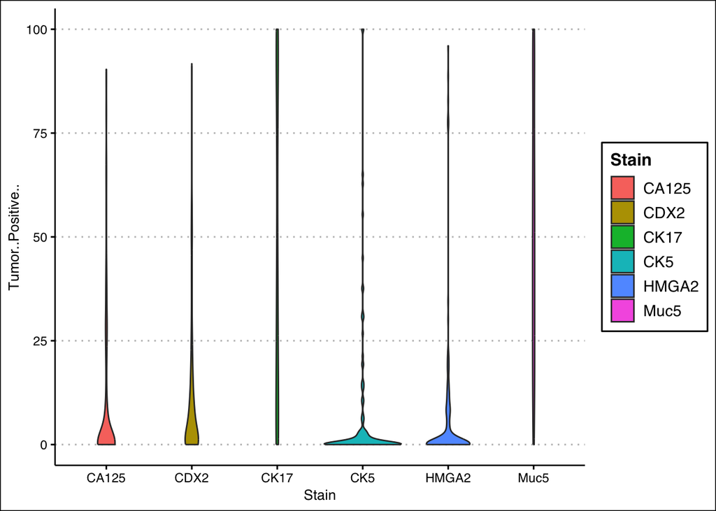

```r
# Violin plots
violin_acinar_trimmed <- distrib_a %>%
  ggplot(aes(x = Stain, y = Tumor..Positive.., fill = Stain)) +
  geom_violin(trim = TRUE) +
  theme_clean()

violin_acinar_trimmed
```

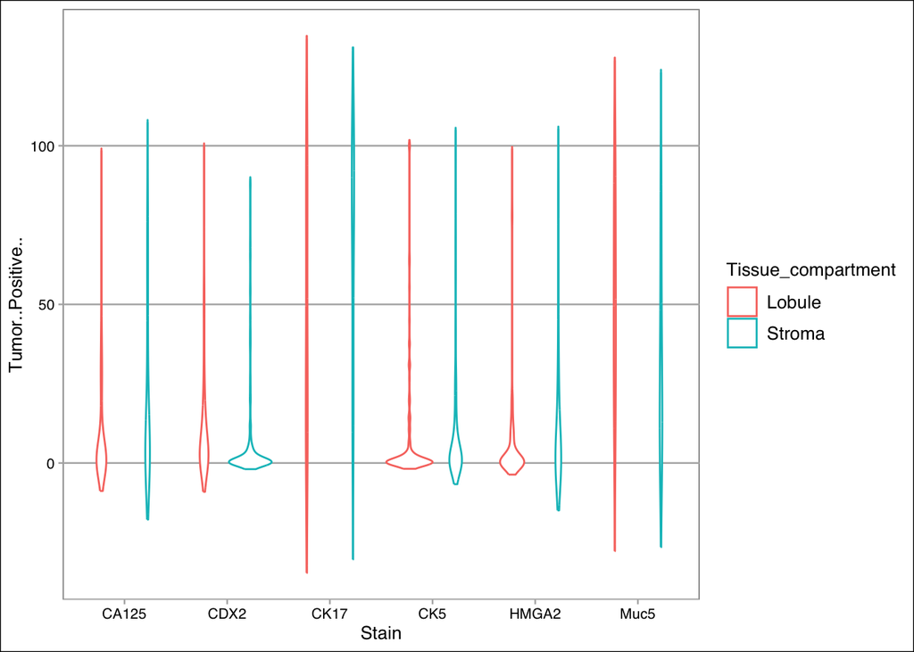

```r
#Violin plots for both compartments
distrib_all <- all_combined[, c(1, 2, 3, 5, 11, 12)]

violin_both_untrimmed <- distrib_all %>%
  ggplot(aes(x = Stain, y = Tumor..Positive.., color = Tissue_compartment)) +
  geom_violin(trim = FALSE, adjust = 2) +
  theme_calc()

violin_both_untrimmed
```

```r
Plasticity_ID <- m_Crows
Plasticity_ID$PKR <- rownames(Plasticity_ID)
# 'Basal' and 'Classical' both go to the moderate category


Plasticity_ID %>% count(Plasticity)
```

```
##   Plasticity  n
## 1      Basal  2
## 2  Classical  1
## 3  Extensive  4
## 4   Moderate  7
## 5       None  7
## 6     Slight 10
```

```r
Plasticity_ID <- Plasticity_ID %>% mutate(Plasticity = ifelse(grepl('Basal', .$Plasticity), 'Moderate', .$Plasticity))
Plasticity_ID <- Plasticity_ID %>% mutate(Plasticity = ifelse(grepl('Classical', .$Plasticity), 'Moderate', .$Plasticity))
Plasticity_ID %>% count(Plasticity)
```

```
##   Plasticity  n
## 1  Extensive  4
## 2   Moderate 10
## 3       None  7
## 4     Slight 10
```

```r
# Fraction of any type of switching; 24/31 ≈ 77,4%

range(all_combined_exl$Num.Detections)
```

```
## [1] 299 864
```

```r
# between 299-864 cells in ROIs.
```